# El rendimiento académico, una explicación alternativa a la desigualdad social en el conocimiento cívico.

Primer avance: Taller de investigación II

Francisco Meneses-Rivas

22 de septiembre de 2019

# Introduccion

El conocimiento cívico y ciudadano (i.e. habilidades y conocimientos necesarios para la vida ciudadana) es actualmente promovido por diversos agentes a nivel académico, estatal e internacional. Este conocimiento es sumamente relevante si se considera sus efectos positivos sobre la intención de participación, en un contexto de apatía política y baja participación de estratos bajos y jóvenes (Janmaat, 2013; Contreras & Navia, 2010; Browne & Elming, 2015; Miranda, Castillo & Sandoval-Hernández, 2015). Igualmente, en el contexto de los nuevos movimientos sociales que buscan reivindicar los derechos de distintos grupos tradicionalmente discriminados, el conocimiento cívico ha demostrado estar relacionado con el respeto a los derechos humanos de estos grupos (Miranda, Castillo & Cumsille, 2018; Caro, Schulz, 2012). También, el tener más conocimiento cívico se relaciona con estar en desacuerdo con la corrupción y con la valoración positiva de la democracia como sistema representativo, lo cual, según Hastedt (2016), es fundamental en un contexto de resurgimiento de los gobiernos autoritarios. En suma, el conocimiento cívico puede ayudar a las personas a incorporar los principios democráticos de los derechos humanos y, por ello, debe buscarse las maneras de fomentarlo y hacer más útiles las políticas que buscan incorporarlo como ramo dentro de la educación secundaria.

Las investigaciones actuales han propuesto que el conocimiento cívico es especialmente influido por variables de origen socioeconómico (Agencia de Calidad de la Educacion, 2017; Schulz, 2011; Castillo, Miranda, Bonhmme, Cox & Bascopé, 2015; Diazgranados & Sandoval-Hernández, 2017; Treviño, Béjares, Villalobos & Naranjo, 2017), dando cuenta de lo que se denominara desde este punto, la “Desigualdad social del conocimiento cívico”, sin embargo, no han controlado dicho efecto en función de las capacidades académicas, lo cual puede generar errores de sobrestimación del efecto. Proponer el origen socioeconómico como factor fundamental para explicar el conocimiento cívico, podría llevar a pensar en alguna medida, que este es transmisible de manera intergeneracional a través de la socialización familiar. Explicarlo de dicho modo seria ignorar que al igual que otras materias, el conocimiento cívico es un conjunto de conocimientos y habilidades que se adquieren a partir de procesos cognitivos de aprendizaje escolar, y que dependen por ello, del desarrollo cognitivo anterior del estudiante y de motivación por la asignatura para ser incorporado. Podría discutirse a lo anterior, que bien los padres pueden enseñar conocimientos del sistema político a sus hijos, pero para probar esta idea, sería necesario controlar por el desempeño académico de los estudiantes, cara no confundir la transmisión de conocimientos con transmisión de habilidades académicas. Aún más, en función de esta reflexión, puede criticarse que parte de la relación entre conocimiento cívico y origen socioeconómico es espuria y se debe más bien a la influencia del origen socioeconómico en el rendimiento académico. Esta propuesta no niega en ni un sentido que existe la desigualdad social del conocimiento cívico, sino que más bien, propone que esta se explica, por la influencia del nivel socioeconómico en el rendimiento académico y en el interés sobre las materias políticas y sociales.

Se hipotetiza que el *rendimiento académico* explica la relación entre el *origen socieconomico* y el *conocimiento cívico*, en consideración de tres argumentos.

En primer lugar, puede suponerse que existe una relación entre el conocimiento cívico y el rendimiento académico, dado que ambas variables son afectadas por el estatus y el capital cultural de los padres de manera coherente. Desde los planteamientos de la línea de la reproducción cultural (Bonal, 1998) de Bourdieu, Passeron y de Bernstein, se plantea que los personas que son hijos de sectores más acomodados y con más recursos educativos, tendrán más ventajas en el sistema educativo, ya sea porque incorporan pautas de lenguaje más complejas, como plantea Bernstein (1977), o porque poseerán mayor interés por el aprendizaje, mejores capacidades y mayor concordancia de hábitos con el colegio (Bourdieu, 1979; Vargas-Salfate, Oyanedel & Torres-Vallejos, 2014; Dukuen, 2015). En coherencia con estos planteamientos y más contextualizado al caso chileno, Dante Contreras (2012), investigador principal del proyecto FONIDE N°: FE11139, concluye que el capital cultural de los padres, puntualmente el capital objetivado y el incorporado, poseen un efecto positivo sobre los resultados de los alumnos chilenos en la prueba PISA. Por su parte, y como ya se ha señalado, el conocimiento cívico es influenciado por las mismas variables, como la cantidad de libros que se posee en el hogar. En función de que tanto el conocimiento cívico como el rendimiento académico son influidos por el capital cultural, es posible hipotetizar que existe una relación entre ambas variables.

En segundo lugar, es posible hipotetizar una relación entre rendimiento académico y conocimiento cívico ya que ambos requieren un conjunto de habilidades y destrezas semejantes (i.e. conocimientos, aplicación y razonamiento). Según el informe de la Agencia de la Calidad de la Educación del MINEDUC (2016) el conocimiento cívico mide dos dominios cognitivos, los conocimientos y el razonamiento-análisis (Schulz, Ainley, Fraillon, Losito y Agrusti, 2016), mientras que los conocimientos requieren primero el acceso a la información y segundo la capacidad de memorizar. Por su parte la prueba SIMCE evalúa los contenidos relativos a las Bases Curriculares (Mineduc, 2015), según las cuales se establecen tres habilidades a evaluar dentro de la prueba de lenguaje en las pruebas de Lenguaje, Matemáticas y Ciencias, los cuales son Conocimientos, Aplicación y Razonamiento. Si bien son tres habilidades en ves de dos, como en el caso de la prueba del conocimiento cívico, si se mira con detalle a que refiere “razonamiento y análisis” podemos dar cuenta de que involucra la Aplicación de los conocimientos cívicos a situaciones más amplias, así como el razonamiento para evaluar propuestas de soluciones, dando cuenta de que se encuentran presentes las dimensiones de aplicación y razonamiento en la prueba de la ICCS. Cabe agregar, que las tres pruebas de SIMCE exigen ser capaz de analizar información para generar deducciones u opiniones justificadas. Incluso José Valenzuela (2015) en su tesis magistral plantea y genera evidencia en torno a la existencia de una variable latente anterior a estas tres pruebas SIMCE, justificando dicho resultado en base a que las tres requieren habilidades semejantes basadas en el análisis de información. En suma, podemos ver que ambas pruebas, tanto la prueba SIMCE como la ICCS evalúan las habilidades de recordar conocimientos, aplicarlos y reflexionar.

En tercer lugar, centrándonos en la comprensión lectora dentro del rendimiento académico, puede argumentarse que esta, como expresión del manejo del lenguaje, es fundamental en el proceso de incorporación del mundo político (Nie, Junn, Stehlik-Barry 1996; Álvarez, 2003), por lo cual se espera que haya una relación especialmente fuerte entre el resultado de la prueba de lenguaje y la prueba de conocimiento cívico.

Por su parte, es razonable hipotetizar que el interés por la política y las temáticas sociales puede explicar la relación entre conocimiento cívico y capital cultural de los padres, si se considera, primero, que el capital de los padres tiene un efecto sobre el interés por la política y participación (Kriger y Dukuen 2012), y segundo que el interés y la motivación son fundamentales en el proceso de aprendizaje en distintas áreas (Carrillo, Padilla, Rosero y Villagómez, 2009; Lozano, García-Cueto y Gallo, 2000; Mateos, Bejarano, Ezquerro y López-Fernández, s.f.). Además, según lo señalado por Schulz (2016), los espacios para discusiones sobre temas políticos y sociales tienen una capacidad predictiva sobre el conocimiento cívico de los estudiantes. En relación a lo que plantea el autor y considerando la importancia de la motivación por la materia en el aprendizaje, puede pensarse que parte del efecto de estos espacios de discusión es que motivan a los estudiantes sobre la materia, lo cual cobra sentido si se considera que las clases participativas de aprendizaje cooperativo tienen un efecto sobre la motivación de los estudiantes (Méndez, 2015).

En suma, el objetivo de este trabajo puede ser expresado en la siguiente pregunta

- ¿En qué medida el rendimiento académico y el interés político son capaces de explicar la desigualdad social del conocimiento cívico según?

## Conceptos

Conocimiento cívico y ciudadano, es entendido como conjunto de saberes y habilidades que son necesarios para la vida en ciudadanía (ICCS, 2016). En términos de habilidades el conocimiento cívico requiere de la habilidad de reflexionar a partir de información y conceptos, así como de poder tener una opinión crítica y poder evaluar propuestas. En términos de contenidos, los saberes propios de este constructo se definen en la tabla 1. La bibliografía ha señalado hasta ahora que el conocimiento cínico es influenciado por variables socioeconómicas. Se ha demostrado igualmente que este efecto es más producido por la educación y el número de Libros en el lugar que por la ocupación, dando luces respecto al carácter cultural del fenómeno (e.g. Castillo, Miranda, Bonhomme, Cox & Bascopé, 2014). Por otro lado, otros autores han explorado el efecto de variables de la escuela sobre el conocimiento cinco a partir de las cuales se puede decir que un clima más abierto a la discusión y una cultura participativa a nivel escuela son propicios para el conocimiento cívico (Schulz, 2016). Estas son variables fundamentales que seran invluidas en trabajos posteriores.

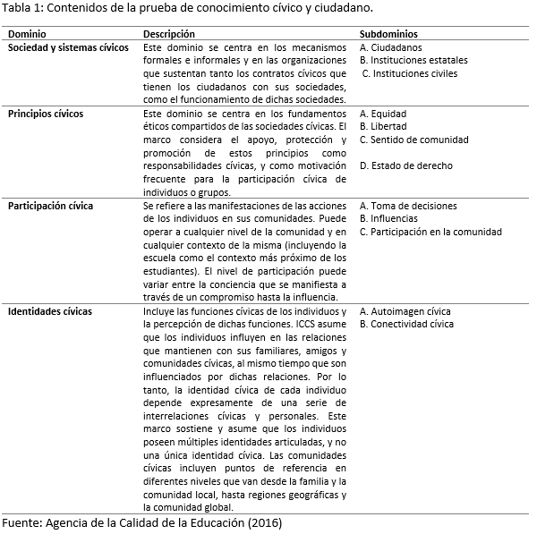

Por desigualdad social del conocimiento cívico este artículo se refiere a la relación positiva que existente entre el conocimiento cívico recién definido y el origen socioeconómico. Por origen socioeconómico, se entiende la relación entre el estatus ocupacional, el nivel educativo alcanzado, y la cantidad de libros en el hogar (ICCS, 2016; Mineduc, 2016). Esta variable es bastante semejante al estatus socioeconómico (SES), solo que la variable origen socioeconómico de la ICCS, no incorpora los ingresos, como usualmente lo hace el SES (Burgard y Stewart, 2003) e incorpora además la cantidad de libros. El que no se incorporen los ingresos es sopesado por incorporar ocupación, que es un mejor indicador de ingresos a largo plazo que la información de ingresos recopilada en cualquier momento dado, porque a corto plazo, los ingresos pueden ser bastante volátiles (Williams y Collins 1995).

Siguiendo con la desigualdad social del conocimiento cívico, se podria afirmar, que esta es parte de un proceso más amplio de desigualdad sociocultural de la política, sobre la cual Bryony Hoskinsa, Jan Germen Janmaat, Christine Han y Daniel Muijs (2016) realizan muy buenas observaciones. A partir de datos mixtos, en distintos países de Europa, los autores dan cuenta como un menor nivel socioeconómico se relaciona con un peor desempeño académico, lo que lleva a las personas a tener una autoevaluación general deficientes de si mismos, y por ello, una baja autoeficacia política, la cual se relaciona igualmente con baja intención de voto. Podría decirse que esta investigación sigue una lógica semejante a la de los autores, agregando a la baja autoeficacia, las dificultades que implica tener una baja capacidad de aprendizaje y mal desarrollo de habilidades en la incorporación de conocimientos y destrezas necesarias para la vida cívica y ciudadana.

El rendimiento académico será considerado como medida de las capacidades del alumno, que expresa lo que éste ha aprendido a lo largo del proceso formativo“(EcuRed, 2019). Para trabajar con esta variable se utilizará la prueba SIMCE, la cual, justamente busca medir los logros de aprendizaje de los estudiantes chilenos (Mineduc, 2019). Según Barahona (2014) Existe un consenso en que los factores asociados al desempeño académico pueden tener su origen en dos grandes ámbitos: en los determinantes personales y en los determinantes sociales, aunque este consenso puede ser interpelado por Lara, Mizala & Repetto, 2010, quienes demustran el efecto que pueden tener las practicas docentes, sugiriendo, entre otras cosas, que discutir la materia en clases es positivo para el rendimiento, resultados coherentes con los resultados presentados por Schulz (2016), según quien, en 17 países un clima abierto a la discusión en el aula es un buen predictor de rendimiento en conocimiento cívico. Ahora bien, si se reconsidera lo planteado por Méndez (2015), quien da cuenta de que metodologías participativas generan un efecto positivo en la motivación por la asignatura y que el interés por la misma es fundamental en el aprendizaje (Carrillo, Padilla, Rosero y Villagómez, 2009; Lozano, García-Cueto y Gallo, 2000; Mateos, Bejarano, Ezquerro y López-Fernández, s.f.), podemos pensar que parte del efecto del clima participativo pasa por el interés de los estudiantes sobre temas de política y sociedad. Para este trabajo incluiremos solo el interés por la política.

# Datos, variables y metodología.

Para trabajar esta propuesta se utilizó la base de datos internacional ICCS 2016, la cual fue cruzada con los resultados de la prueba SIMCE nacional chilena. Se obtuvo un total de 4371 casos, si se eliminan los perdidos de todas las variables utilizadas. Las variables que se utilizaron fueron el conocimiento cívico, en su primera estimación (PV1CIV), el origen socioeconómico nacional estandarizado (S_NISB), el interés político del estudiante y de los padres (S_SINT, S_HINT). Además, se utilizó el promedio en las pruebas de lenguaje, matemáticas y ciencia, para representar el rendimiento académico, mientras que la variable de interés político es dicotomizada para ser utilizada en las regresiones.

- conocimiento cívico (PV1CIV)
- el origen socioeconómico nacional estandarizado (S_NISB) basado en:
  - cantidad de libros en la casa (S_HOMLIT)
  - Mayor nivel educativo entre los padres (S_HISCED)
  - Mayor estatus ocupacional entre los padres (S_HISEI)
- Rendimiendimeinto academico, equivalente al promedio de
  - SIMCE Lenguaje
  - SIMCE Matematicas
  - SIMCE Ciencias Naturales
- interes politico del estudiante (S_SINT) y ademas,
  - Mayor interes politico entre los padres (S_HINT)

En términos metodológicos este articulo utiliza primero regresiones lineales múltiples con la intención de evaluar todos los supuestos posibles de validez, luego se realiza path análisis, para graficar las relaciones, evaluar el ajuste del modelo y calcular el porcentaje del efecto del origen socioeconómico sobre le conocimiento cívico que corresponde al rendimiento académico.

```r
iccssimce <- read_dta("iccs_simce.dta")
#View(iccssimce[1,])

data <- iccssimce %>% select("p.leng"=ptje_lect8b_alu, "p.mat"=ptje_mate8b_alu, "p.nat"=ptje_nat8b_alu, "p.civ"=PV1CIV, "Or.socec"=S_NISB, "int_pol_es"=S_SINT, "ip_padres"=S_HINT) %>% as.data.frame()

data<-na.omit(data)

data$ra<- (data$p.leng + data$p.mat + data$p.nat)/3
data$IPE_DIC<-ifelse(data$int_pol_es>2,1,0)
```

# Descriptivos y Bivariados

## tabla 2: Resumen de las variables

```r
stargazer(data, type="text")
```

```
##
## ===================================================================
## Statistic    N    Mean   St. Dev.   Min   Pctl(25) Pctl(75)   Max
## -------------------------------------------------------------------
## p.leng     4,371 249.604  50.443  125.950 211.470  287.215  373.160
## p.mat      4,371 271.768  50.528  141.040 234.060  309.045  394.390
## p.nat      4,371 272.915  50.584  147.070 234.770  309.420  417.130
## p.civ      4,371 495.226  93.718  179.410 429.015  562.985  782.730
## Or.socec   4,371  0.159   1.045   -2.700   -0.650   0.990    2.490
## int_pol_es 4,371  1.047   0.792      0       1        1        3
## ip_padres  4,371  1.824   0.806      0       1        2        3
## ra         4,371 264.762  44.930  153.427 229.962  298.935  381.673
## IPE_DIC    4,371  0.055   0.227      0       0        0        1
## -------------------------------------------------------------------
```

Como puede verse todas las variables tienen un n de 4371. Respecto a la variable dependiente conocimiento cívico y ciudadano (p.civ), esta posee un promedio de 495,226 y una desviación estándar de 93,718. Por su parte, el promedio del rendimiento académico medido a través del promedio de la prueba SIMCE de matemáticas, lenguaje y ciencias (ra), es de 264,762 puntos, con una desviación estándar aproximada de 45 puntos. .

## Grafico de la relacion entre Conocimiento civico y Rendimiento Academico

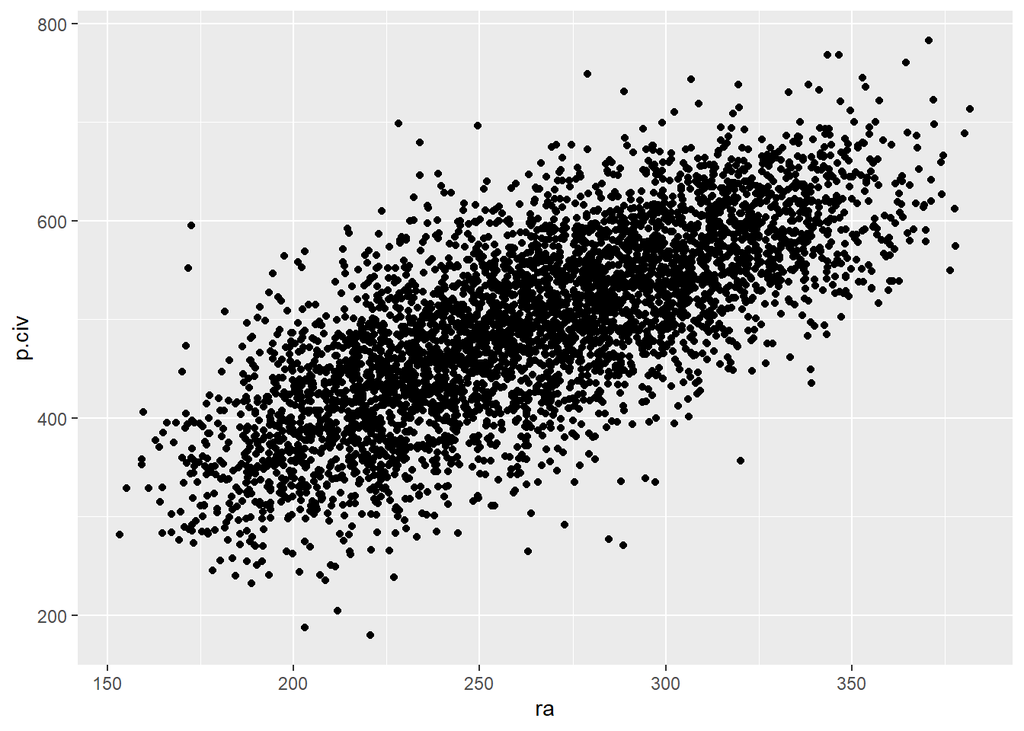

A partir de este grafico de dispersión, puede esperarse una relación lineal moderada y positiva, pues, como se observa en el gráfico, alumnos con mayores puntajes en su rendimiento académico presentan igualmente mayores puntajes en el conocimiento civico. Se procede a probar esta hipotesis a partir de la pruba RLM

# RLM

```r
reg1<- lm(p.civ ~ Or.socec, data=data)
reg2<- lm(p.civ ~ ra, data=data)
reg3<- lm(p.civ ~ IPE_DIC, data=data)
reg5<- lm(p.civ ~ Or.socec + IPE_DIC + ra, data=data)
stargazer(list(reg1,reg2,reg3,reg5), type= "html")
```

|  | *Dependent variable:* |  |  |  |
| --- | --- | --- | --- | --- |
|  | p.civ |  |  |  |
|  | (1) | (2) | (3) | (4) |
| Or.socec | 39.035*** |  |  | 12.291*** |
|  | (1.222) |  |  | (1.012) |
| ra |  | 1.529*** |  | 1.403*** |
|  |  | (0.021) |  | (0.023) |
| IPE_DIC |  |  | 17.719*** | 10.789*** |
|  |  |  | (6.230) | (4.176) |
| Constant | 489.027*** | 90.273*** | 494.257*** | 121.257*** |
|  | (1.291) | (5.762) | (1.457) | (6.231) |
| Observations | 4,371 | 4,371 | 4,371 | 4,371 |
| R<sup>2</sup> | 0.189 | 0.538 | 0.002 | 0.554 |
| Adjusted R<sup>2</sup> | 0.189 | 0.538 | 0.002 | 0.554 |
| Residual Std. Error | 84.385 (df = 4369) | 63.730 (df = 4369) | 93.642 (df = 4369) | 62.613 (df = 4367) |
| F Statistic | 1,021.076*** (df = 1; 4369) | 5,081.179*** (df = 1; 4369) | 8.090*** (df = 1; 4369) | 1,807.731*** (df = 3; 4367) |
| *Note:* | p<0.1; p<0.05; p<0.01 |  |  |  |

En síntesis, podemos decir que el interés político y, muy especialmente, el rendimiento académico, son capaces de controlar alrededor de la mitad del efecto del origen socioeconómico. Dicho de otro modo, la desigualdad en el conocimiento cívico se explica en buena medida, aunque no completamente, por las diferencias en el rendimiento académico. Para evaluar la validez de estas conclusiones, se procede a evaluar los supuestos de este modelo.

## Analisis de supuestos y validez

### Analisis grafico de linealidad

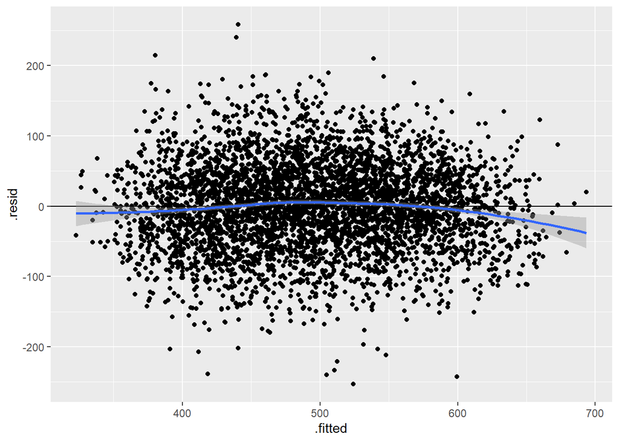

Como puede observarse en el gráfico, existe una relación entre los residuos y los valores predichos. Para evaluar si es que esto se debe a la existencia de una relación lineal no especificada, se procede a realizar el test de especificación de Ramsey.

### Estadistico RESET

```r
reg5.1 <- lm(p.civ ~ Or.socec + IPE_DIC + ra + I(.fitted^2),
data = supuestos)

# F test of model difference
anova(reg5, reg5.1)
```

```
## Analysis of Variance Table
##
## Model 1: p.civ ~ Or.socec + IPE_DIC + ra
## Model 2: p.civ ~ Or.socec + IPE_DIC + ra + I(.fitted^2)
##   Res.Df      RSS Df Sum of Sq      F    Pr(>F)
## 1   4367 17120492
## 2   4366 16993277  1    127215 32.685 1.156e-08 ***
## ---
## Signif. codes:  0 '***' 0.001 '**' 0.01 '*' 0.05 '.' 0.1 ' ' 1
```

#### Evaluando la no linealidad del efecto del rendimiento academico sobre el conocimieto civico.

```r
data$ra_ra<-data$ra*data$ra
reg5_1<- lm(p.civ ~ Or.socec + IPE_DIC + ra + ra_ra, data=data)
stargazer(reg5_1, type= "html")
```

|  | *Dependent variable:* |
| --- | --- |
|  | p.civ |
| Or.socec | 12.580*** |
|  | (1.010) |
| IPE_DIC | 12.894*** |
|  | (4.178) |
| ra | 2.655*** |
|  | (0.223) |
| ra_ra | -0.002*** |
|  | (0.0004) |
| Constant | -40.319 |
|  | (29.238) |
| Observations | 4,371 |
| R<sup>2</sup> | 0.557 |
| Adjusted R<sup>2</sup> | 0.557 |
| Residual Std. Error | 62.392 (df = 4366) |
| F Statistic | 1,373.412*** (df = 4; 4366) |
| *Note:* | p<0.1; p<0.05; p<0.01 |

##### Corroborando si es el desempeño academico lo que produce el problema.

```r
reg5.1 <- lm(p.civ ~ Or.socec + IPE_DIC + ra + I(.fitted^2),
data = supuestos)

# F test of model difference
anova(reg5_1, reg5.1)
```

```
## Analysis of Variance Table
##
## Model 1: p.civ ~ Or.socec + IPE_DIC + ra + ra_ra
## Model 2: p.civ ~ Or.socec + IPE_DIC + ra + I(.fitted^2)
##   Res.Df      RSS Df Sum of Sq F Pr(>F)
## 1   4366 16995994
## 2   4366 16993277  0    2716.4
```

Agregando el efecto cuadratico de rendimiento academico, deja de ser significativa la diferencia entre el modelo y el modelo extendido, por ello, podemos decir que se ha encontrado la variable que producia el problema.

### Evaluando Multicolinealidad

```r
vif<-vif(reg5)
vif
```

```
## Or.socec  IPE_DIC       ra
## 1.247019 1.004874 1.241633
```

### Evaluando la Homosedastisidad de los residuos

```r
car::ncvTest(reg5)
```

```
## Non-constant Variance Score Test
## Variance formula: ~ fitted.values
## Chisquare = 14.27478, Df = 1, p = 0.00015797
```

```r
lmtest::bptest(reg5)
```

```
##
##  studentized Breusch-Pagan test
##
## data:  reg5
## BP = 16.243, df = 3, p-value = 0.001011
```

En función de estos estadísticos se rechaza la hipótesis nula de error constante, por lo tanto podemos decir que tenemos heteroscedasticidad, lo cual hace necesario hacer un análisis a partir de la corrección de errores estándares robustos.

#### Calculando una regresion robusta

```r
#no me reconose el comando vcov=vcovHC
reg5_1rob <- coeftest(reg5, df = Inf, type = "HC0")
```

### Casos influyentes

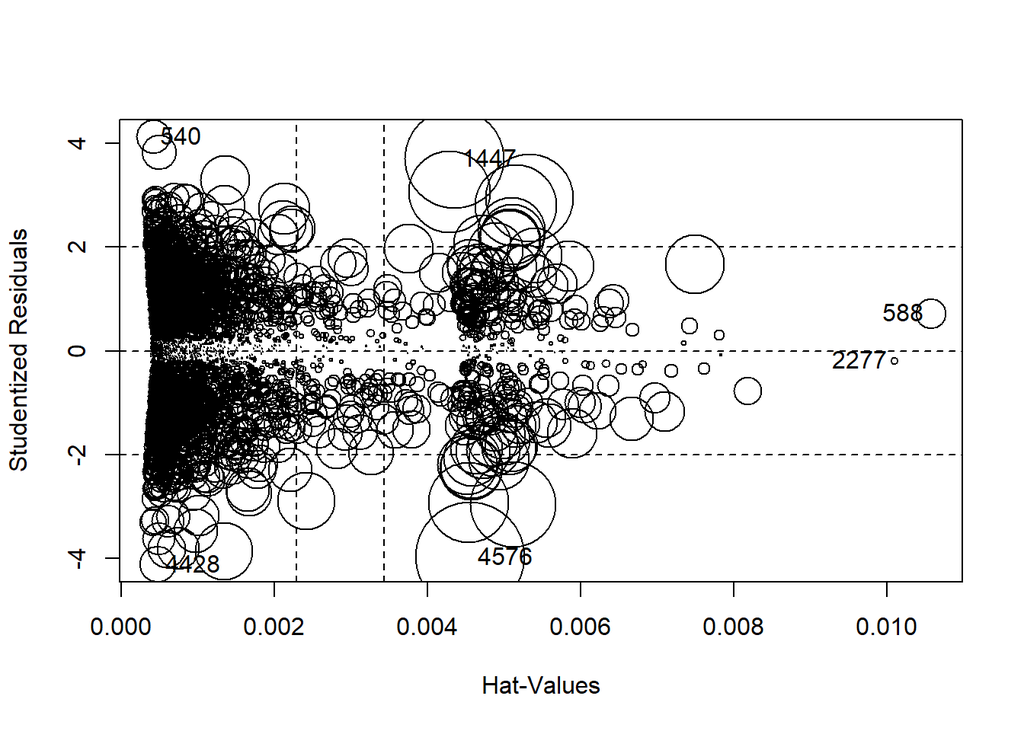

```
##         StudRes          Hat        CookD
## 540   4.1282659 0.0004140021 1.406549e-03
## 588   0.7175080 0.0105725583 1.100342e-03
## 1447  3.7030355 0.0043485057 1.194306e-02
## 2277 -0.1903687 0.0100918836 7.390852e-05
## 4428 -4.1202842 0.0004751437 1.608161e-03
## 4576 -3.9696390 0.0045573554 1.438014e-02
```

```r
influencePlot(reg5_1)
```

```r
# cutoff point
round(4/(4371-4-1),3)
```

```
## [1] 0.001
```

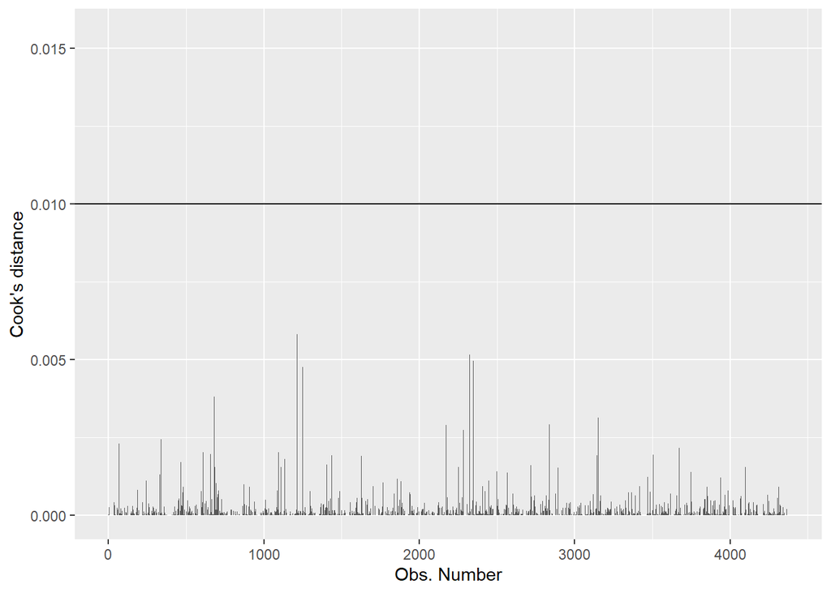

```r
 #create observation id
supuestos$id <- as.numeric(row.names(supuestos))
# identify obs with Cook's D above cutoff
ggplot(supuestos, aes(id, .cooksd))+
geom_bar(stat="identity", position="identity")+
xlab("Obs. Number")+ylab("Cook's distance")+
geom_hline(yintercept=0.01)+
geom_text(aes(label=ifelse((.cooksd>0.03),id,"")),
vjust=-0.2, hjust=0.5)
```

### Normalidad

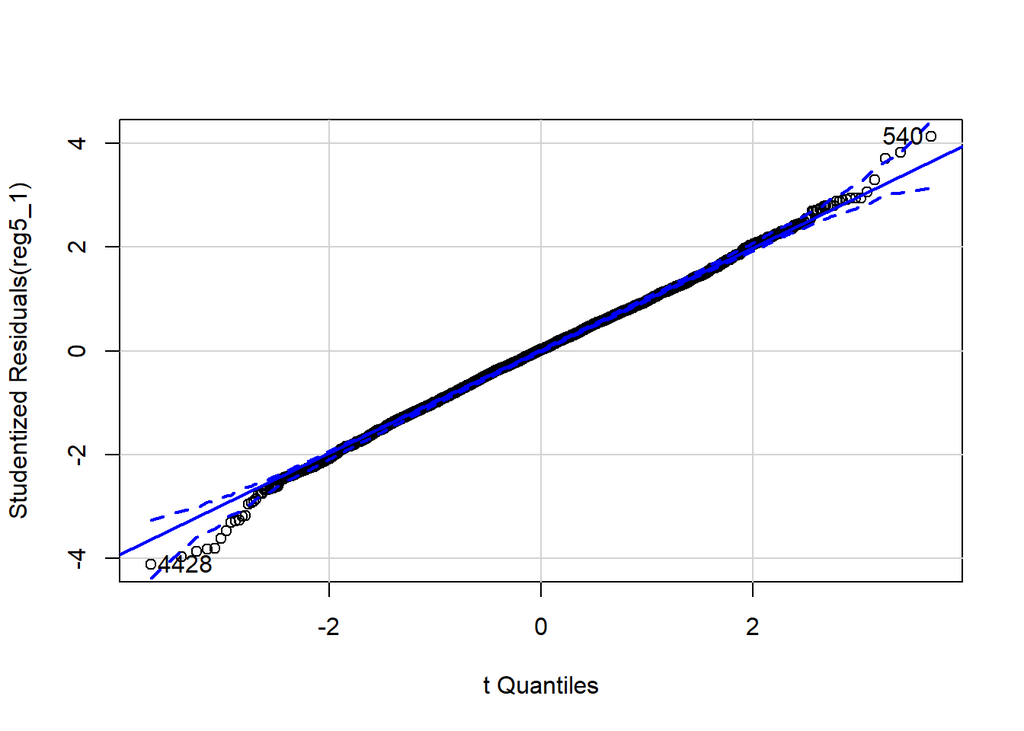

```
##  540 4428
##  466 3759
```

```r
car::qqPlot(reg5_1, distribution = "t", simulate = TRUE)
```

```r
supuestos1 <- augment_columns(reg5_1, data)
shapiro.test(supuestos1$.resid)
```

```
##
##  Shapiro-Wilk normality test
##
## data:  supuestos1$.resid
## W = 0.99841, p-value = 0.0002338
```

En consideracion del estadistico Shapiro-Wilk, y del p de significacion significativo, debemos decir que hay una diferencia entre la distribucion de los residuos y la distribucion de una normal. Por ello, es pertinente considerar que existen variables influyentes que no estan siendo incorporadas en el modelo, lo cual es bastante probable si se considera que este modelamiento no incluye variables de nivel escolar, las cuales seran incorporadas en trabajos futuros.

```r
stargazer(reg5, reg5_1, reg5_1rob, type="html",column.labels = c("OLS","efecto cuadratico","Robusto",single.row=TRUE),
          model.names = FALSE)
```

|  | *Dependent variable:* |  |  |
| --- | --- | --- | --- |
|  | p.civ |  |  |
|  | OLS | efecto cuadratico | Robusto |
|  | (1) | (2) | (3) |
| Or.socec | 12.291*** | 12.580*** | 12.291*** |
|  | (1.012) | (1.010) | (1.012) |
| IPE_DIC | 10.789*** | 12.894*** | 10.789*** |
|  | (4.176) | (4.178) | (4.176) |
| ra | 1.403*** | 2.655*** | 1.403*** |
|  | (0.023) | (0.223) | (0.023) |
| ra_ra |  | -0.002*** |  |
|  |  | (0.0004) |  |
| Constant | 121.257*** | -40.319 | 121.257*** |
|  | (6.231) | (29.238) | (6.231) |
| Observations | 4,371 | 4,371 |  |
| R<sup>2</sup> | 0.554 | 0.557 |  |
| Adjusted R<sup>2</sup> | 0.554 | 0.557 |  |
| Residual Std. Error | 62.613 (df = 4367) | 62.392 (df = 4366) |  |
| F Statistic | 1,807.731*** (df = 3; 4367) | 1,373.412*** (df = 4; 4366) |  |
| *Note:* | p<0.1; p<0.05; p<0.01 |  |  |

[no analiso este grafico por que no logre utilizar valores robustos, por ello cualquier conclucion de la comparacion de los modelos no seria un aporte para el trabajo]

A partir del analisis de la regresion y sus supuestos de validez, puede decirse que las concluciones son relativamente validaz, aunque el modelo precentaba problemas de especificacion de relaciones no lineales, de normalidad de los residuos y de inconstancia de los errores. Problemas los cuales se ha solucionado parcialmente, llegando a la conclucion de una relacion cuadratica.

# PATH analisis

```r
model1<-
' ra ~ Or.socec
  int_pol_es ~ ip_padres
  ip_padres ~ Or.socec
  p.civ ~ ra + int_pol_es + Or.socec
  ra ~~int_pol_es


'

fit1<- sem(model1, data=data, ordered = c("int_pol"))
summary(fit1, fit.measures=T, standardized=T)
```

```
## lavaan 0.6-5 ended normally after 89 iterations
##
##   Estimator                                       DWLS
##   Optimization method                           NLMINB
##   Number of free parameters                         15
##
##   Number of observations                          4371
##
## Model Test User Model:
##                                               Standard      Robust
##   Test Statistic                                 8.455       9.669
##   Degrees of freedom                                 3           3
##   P-value (Chi-square)                           0.037       0.022
##   Scaling correction factor                                  0.921
##   Shift parameter                                            0.493
##     for the simple second-order correction
##
## Model Test Baseline Model:
##
##   Test statistic                              2458.635    1997.063
##   Degrees of freedom                                 6           6
##   P-value                                        0.000       0.000
##   Scaling correction factor                                  1.232
##
## User Model versus Baseline Model:
##
##   Comparative Fit Index (CFI)                    0.998       0.997
##   Tucker-Lewis Index (TLI)                       0.996       0.993
##
##   Robust Comparative Fit Index (CFI)                            NA
##   Robust Tucker-Lewis Index (TLI)                               NA
##
## Root Mean Square Error of Approximation:
##
##   RMSEA                                          0.020       0.023
##   90 Percent confidence interval - lower         0.004       0.008
##   90 Percent confidence interval - upper         0.037       0.039
##   P-value RMSEA <= 0.05                          0.999       0.998
##
##   Robust RMSEA                                                  NA
```

[output cut: 29 more lines]

```
##    .int_pol_es        2.410    0.482    5.001    0.000    2.410    0.087
##
## Intercepts:
##                    Estimate  Std.Err  z-value  P(>|z|)   Std.lv  Std.all
##    .ra              261.753    0.614  426.514    0.000  261.753    5.825
##    .int_pol_es        0.166    0.026    6.512    0.000    0.166    0.211
##    .ip_padres         1.785    0.012  150.595    0.000    1.785    2.215
##    .p.civ           116.048    6.130   18.931    0.000  116.048    1.238
##
## Variances:
##                    Estimate  Std.Err  z-value  P(>|z|)   Std.lv  Std.all
##    .ra             1627.225   30.782   52.862    0.000 1627.225    0.806
##    .int_pol_es        0.472    0.012   39.344    0.000    0.472    0.758
##    .ip_padres         0.582    0.011   52.697    0.000    0.582    0.895
##    .p.civ          3866.601   89.167   43.363    0.000 3866.601    0.440
```

```r
a<-(8.45/3)
a
```

```
## [1] 2.816667
```

```r
semPaths(fit1, what="std",layout = "spring",
label.cex=1.5,
edge.label.cex=2,
residuals=F,
edge.color = "Black",
thresholds= F,#Esto saca las lineas dentro de los cuadrados que representan las variables.
intercepts = F, shapeInt = "Null", structural = F, freeStyle = 1, pastel =F,  layoutSplit = F, rainbowStart = 0, exoCov = F, color = "white", panelGroups = T, subRes = 4, covAtResiduals = F)
```

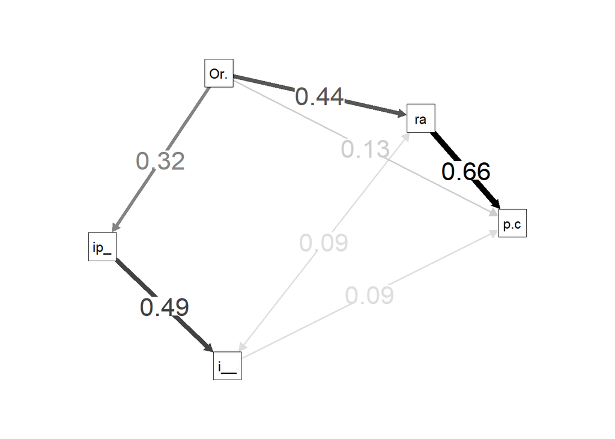

Si analisamos el grafico, podemos ver que las variables que van desde el origen socieconomico al puntaje en conocimiento civico, por el lado del rendimiento academico poseen relaciones más fuertes y constantes que el sendero que va por el camino del interes politico, el cual si bien es constante desde el origensocieconomico, pasando por el interes del padre hasta el interes del hijo, deja de ser un efecto notorio al pasar a explicar el conocimiento civico. Con estos resultados, se refuerza la idea de que el rendimiento academico es mas importante que el interes por los asuntos politicos y sociales para predecir el conocimiento civico. Se procede a calcular la proporcion del efecto del origen socioeconomico que corresponde a cada una de las rutas.

```r
#Calculo del porcentaje de efecto explicado por rendimiento academico

#Efecto indirecto a traves de interes en la politica 0.014
a<-0.32*0.49*0.09

#Efecto indirecto a traves de rendimiento academico 0.290
b<-0.44*0.66

#Efecto directo
c<- 0.13

#Efecto total 0.434
d<- 0.014 + 0.290 + 0.13

#Porcentaje del efecto que pasa a traves del rendimiento academico 66,8%
e<- (0.290*100)/0.434
e
```

```
## [1] 66.82028
```

```r
#Porcentaje del efecto que pasa a traves del interes por la politica 3.22%
f<- (0.014*100)/0.434
f
```

```
## [1] 3.225806
```

```r
#Porcentaje del efecto del origen socieconomico que este estudio no ha podido controlar 29.95392%.
g<- (0.130*100)/0.434
g
```

```
## [1] 29.95392
```

En consideración de estos cálculos, y a modo de resumen de los resultados, podemos decir que el rendimiento académico explica el 66,8% del efecto de la desigualdad socioeconómica y cultural sobre el conocimiento cívico, mientras que la transmisión de interés político y motivación por el área solo logra explicar el 3,2% de dicha desigualdad, lo cual puede interpretarse como una desigualdad de habilidades des equitativamente distribuidas y no de un menor interés sobre la materia política que dificulte a los estudiantes de menores recursos apropiarse del conocimiento cívico.

El aproximadamente 30% del efecto que pasa directamente de la desigualdad socioeconómica al conocimiento cívico, se debe probablemente al efecto de poder participar en escuelas donde hay estudiantes con interés político, conocimiento cívico y buen rendimiento académico, con los cuales enriquecerse a partir del efecto de composición y el efecto par. Probar esta hipótesis requiere de un futuro estudio que utiliza multinivel.

Es necesario tomar en consideración para analizar estos resultados, que probablemente, parte del efecto del rendimiento académico corresponde a variables que no están siendo incluidas, pero se reflejan en él, como lo puede ser el tener buenos profesores, preparados para enseñar. Es necesario en trabajos futuros evaluar la importancia de la formación de los profesores y de su grado de confianza respecto a su propio conocimiento cívico.

# Conclusiones preliminares

Este estudio ha intentado explicar el efecto de la desigualdad socioeconómica chilena en la desigualdad en el conocimiento cívico de los estudiantes de 8vo. Como principal resultado, el rendimiento académico (promedio de las pruebas simpe) explica dos tercios del efecto de la desigualdad socioeconómica en el conocimiento cívico, mientras que el interés solo el 3% de dicho efecto. Por ello, y volviendo a la discusión inicial, podemos decir que el efecto de la desigualdad socioeconómica estaba sobredimensionado y no es que el vivir y socializar en un contexto familiar con más libros o más educación genere estudiantes jóvenes interesados por la política y la ciudadanía, sino que más bien, existe una transmisión de habilidades, como propone Bernstein (1976), a lo que se suma la posibilidad de acceder a colegios que preparen mejor a sus hijos en termino de conocimientos y habilidades. Además, se observó una relación no lineal entre el rendimiento académico y el conocimiento cívico, que indica una disminución del efecto para valores altos, esto sugiere que las habilidades requeridas para las pruebas simpen, son igualmente una base necesaria para el conocimiento cívico, sin la cual es difícil obtener puntajes promedio, pero las cuales no son suficientes para obtener puntajes altos.

Para futuros trabajos es necesario incluir el modelamiento multinivel para poder utilizar variables de la escuela, y evaluar que proporción del 30% no explicado del efecto del origen socieconomico al conocimiento civico se debe tanto colegios mas caros, mejores profesores y compañeros y compañeras de mayor capital cultural